# Clustering: Hierarchical

## Where we left off

- **K-means** (Day 19): pick \(K\), then find the \(K\) clusters with the smallest within-cluster variation.
- Two problems:
  - We have to choose \(K\) **before** we see any clusters.
  - Changing \(K\) can **reshuffle** everything. On Day 19’s colleges, going from K = 3 to K = 4, none of the 3 clusters simply split in two: colleges moved between all of them.
- **Hierarchical clustering:** build **one tree** that holds the clusters for every \(K\) at once. Choose \(K\) afterwards, by looking at the tree.

## Nine points

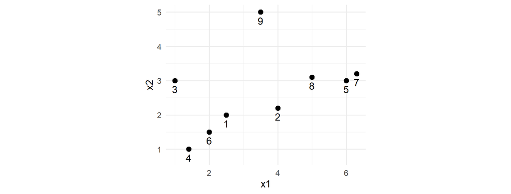

- Start with every point as its own cluster: 9 clusters.
- **Which two points would you join first?**

## The algorithm (ISL Algorithm 12.3)

1. Start with \(n\) clusters, one point each. Compute the **distance** between every pair.
2. **Fuse** the two closest clusters. Record the distance at which they fused.
3. Compute the distance from the new cluster to every other cluster.
4. Repeat 2–3 until everything is one cluster.
- Bottom-up: \(n\) clusters → \(n - 1\) → … → 1. That’s \(n - 1\) fusions.
- Step 3 needs a rule for the distance between **groups** of points.

## The first fusions

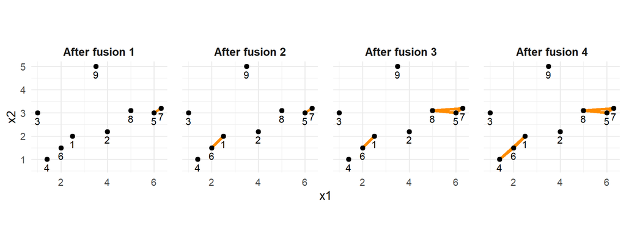

- 5 and 7 (distance 0.36), then 1 and 6 (0.71), then 8 joins {5, 7} (1.30), then 4 joins {1, 6} (1.49).
- **How far is 8 from the group {5, 7}?** It’s 1.00 from 5 and 1.30 from 7.

## Linkage: distance between groups

| Linkage | Distance between groups A and B | 8 to {5, 7} |
| --- | --- | --- |
| **Complete** (R’s default) | the **largest** distance from a point in A to a point in B | 1.30 |
| **Single** | the **smallest** such distance | 1.00 |
| **Average** | the **average** of all the distances | 1.15 |
| Centroid | the distance between the two centroids (as in k-means) |  |

- Complete linkage: 8 is 1.30 from {5, 7}, its distance to the farther point, 7.
- ISL: complete and average are the usual choices; single tends to make long chains (we’ll see one soon).

## The whole tree: a dendrogram

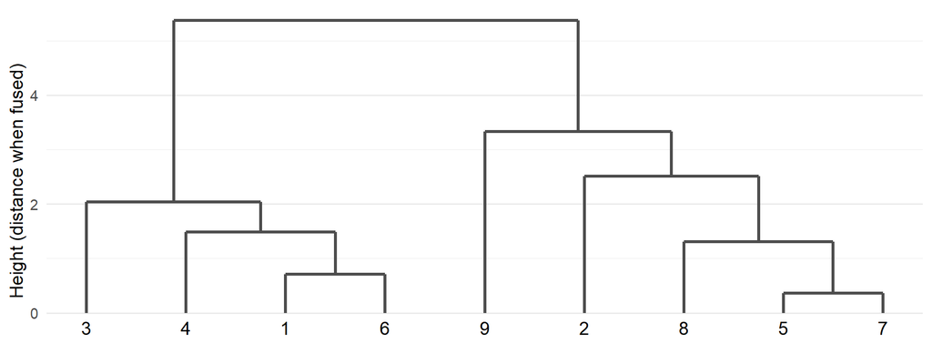

- Each **leaf** at the bottom is a point. Two branches join at the **height** where they fused.
- Bottom: 5 and 7 at 0.36. Top: the last two clusters at 5.37.

## Reading the tree

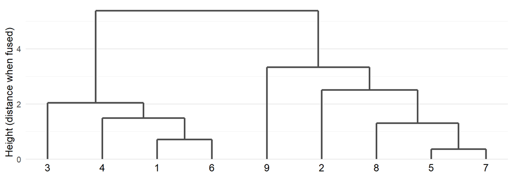

- **Is 9 more similar to 2 or to 5?**
- Is 9 more similar to 2 or to 1?

## Reading the tree: height, not left-to-right

- 9 joins {2, 5, 7, 8} all at once, at height 3.33. The tree **can’t tell** whether 9 is closer to 2 or to 5.
  - Next to each other at the bottom means nothing: each fusion can be drawn either way round. (Actually: 9 to 2 is 2.84, 9 to 5 is 3.20.)
- 9 joins 1 only at the top (5.37), so 9 is **more similar to 2** than to 1.
- Rule: two points are as similar as the **height where their branches first meet**.

## Cutting the tree

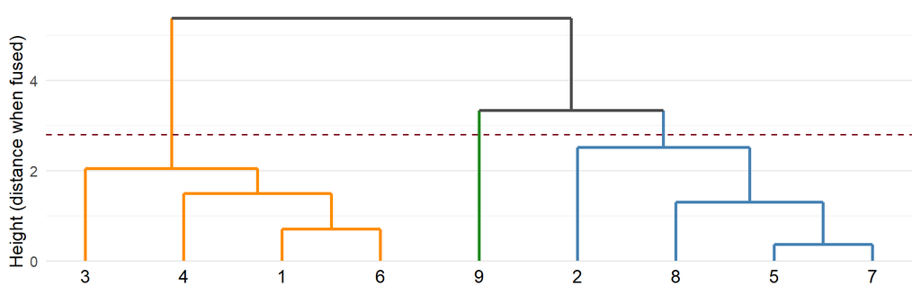

- A horizontal cut at height 2.8 crosses 3 branches: **3 clusters**. Lower cut, more clusters.
- `cutree(hc, k = 3)` picks the height for you; `cutree(hc, h = 2.8)` cuts at that height.

## One tree, every K

- Cut a little lower and **one** cluster splits in two; nothing else moves. The clusters are **nested**.
- Day 19’s 777 colleges, standardized: where each K = 3 cluster’s colleges go at K = 4.

**K-means**

| K = 3 | K = 4: 1 | K = 4: 2 | K = 4: 3 | K = 4: 4 |
| --- | --- | --- | --- | --- |
| cluster 1 | 340 | 43 | 1 | 0 |
| cluster 2 | 11 | 0 | 6 | 71 |
| cluster 3 | 2 | 232 | 71 | 0 |

**Hierarchical (complete)**

| K = 3 | K = 4: 1 | K = 4: 2 | K = 4: 3 | K = 4: 4 |
| --- | --- | --- | --- | --- |
| cluster 1 | 361 | 0 | 0 | 1 |
| cluster 2 | 0 | 400 | 0 | 0 |
| cluster 3 | 0 | 0 | 15 | 0 |

- K-means re-solves the problem for each K; the tree just cuts lower.

## Linkage matters: the world’s cities

> **The same 4,251 cities as Day 19, longitude and latitude only. Cut at K = 6.**

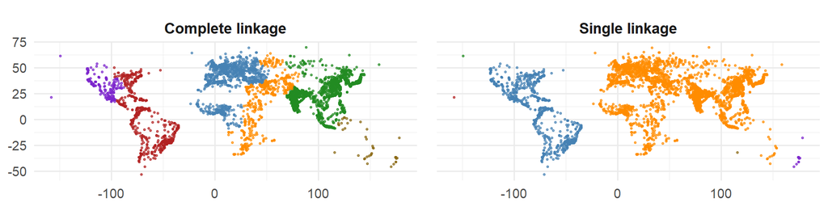

- **Complete:** six regions, a lot like Day 19’s k-means.
- **Single:** 3,331 cities in the Old World, 906 in the Americas, 11 in New Zealand, and Anchorage, Honolulu, Perth each **alone**. Why?

## Why single linkage chains

- Single linkage fuses two groups when **any** two of their points are close.
- Cities are dense from Lisbon to Tokyo: a chain of near neighbors joins them all, long before the groups look like regions.
- So the last clusters to join are the **isolated** cities, far from every other city.
- Useful for finding outliers; usually not what we want for groups. Complete and average linkage give more balanced clusters.

## Choices that matter

- **Distance:** Euclidean, as in KNN and k-means. **Standardize** first, unless the units should count (Day 19).
  - ISL 12.4.3 also uses correlation-based distance: two shoppers are close if they buy the same **kinds** of things, even if one buys more of everything.
- **Linkage:** complete (default), average, or single. Different trees.
- **Where to cut:** look for a height with a big gap between fusions, and think about the use.
- No CV error to settle any of these. Try a few and see if the answer holds up.

## Hierarchical clustering in R

```r
Z <- scale(X)                          # standardize the numeric columns
d <- dist(Z)                           # distances between every pair of rows
hc <- hclust(d, method = "complete")   # or "average", "single"
plot(hc, labels = names, cex = 0.6)    # the dendrogram
clusters <- cutree(hc, k = 3)          # cluster number for each row, K = 3
clusters <- cutree(hc, h = 5)          # or: cut at height 5
```

- `dist()` on \(n\) rows computes \(n(n-1)/2\) distances: 777 colleges is 301,476, fine; 1,000,000 rows would be about \(5 \times 10^{11}\), too many.
- `cutree()` returns cluster numbers, like `km$cluster`: add them with `mutate()`.

## K-means vs hierarchical

|  | K-means | Hierarchical |
| --- | --- | --- |
| Choose K | **before** fitting | **after**, by cutting the tree |
| Change K | re-run; clusters can reshuffle | cut lower; clusters are nested |
| Randomness | random starts (`nstart`) | none: same data, same tree |
| Picture | the clusters | the dendrogram: who is close to whom |
| Big data | fast | slow: every pair of rows |
| Main choices | K, scaling | distance, scaling, linkage, cut |

## Summary

- **Hierarchical clustering:** start with every point alone, fuse the two closest clusters, repeat.
- **Linkage** sets the distance between groups: complete (largest), average, single (smallest; chains).
- **Dendrogram:** similarity = the height where two branches first meet, not left-to-right order.
- **Cut** the tree to get clusters; one tree gives every K, nested.
- Standardize first; no CV error, so check that the clusters hold up.
- **Day 21:** PCA, which summarizes the **columns** instead of grouping the rows.

## For rest of class

- Work on the `day20_activity`
  - 30 of Day 19’s elite colleges: what structure is inside that one cluster?
  - read a dendrogram: who is Claremont McKenna’s closest match?
  - cut the tree, and compare complete, average, and single linkage
- Ask me questions if you run into issues